# quiz 2

2025-09-25

```r
library(readr)
library(ggplot2)
library(ggfortify)
library(MASS)
```

```r
Glakes <- read_csv("C:/mat374/Glakes.csv")
head(Glakes)
```

```
## # A tibble: 6 × 3
##    Case Tonnage  Time
##   <dbl>   <dbl> <dbl>
## 1     1    2213    17
## 2     2    3256    30
## 3     3   12203    68
## 4     4    7021    64
## 5     5     529    11
## 6     6    3192    55
```

a,

```r
model1 <- lm(Time ~ Tonnage, data = Glakes)
summary(model1)
```

```
##
## Call:
## lm(formula = Time ~ Tonnage, data = Glakes)
##
## Residuals:
##     Min      1Q  Median      3Q     Max
## -23.882  -6.397  -1.261   5.931  21.850
##
## Coefficients:
##              Estimate Std. Error t value Pr(>|t|)
## (Intercept) 12.344707   2.642633   4.671 6.32e-05 ***
## Tonnage      0.006518   0.000531  12.275 5.22e-13 ***
## ---
## Signif. codes:  0 '***' 0.001 '**' 0.01 '*' 0.05 '.' 0.1 ' ' 1
##
## Residual standard error: 10.7 on 29 degrees of freedom
## Multiple R-squared:  0.8386, Adjusted R-squared:  0.833
## F-statistic: 150.7 on 1 and 29 DF,  p-value: 5.218e-13
```

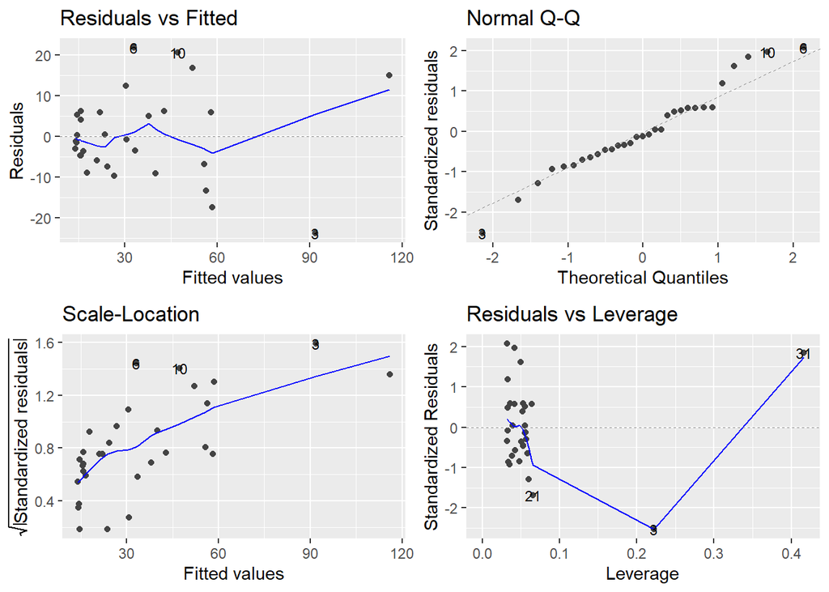

```r
autoplot(model1, label.repel = TRUE, label.size = 3)
```

```r
predict(model1, newdata = data.frame(Tonnage = 10000), interval = "confidence", level = 0.95)
```

```
##       fit      lwr      upr
## 1 77.5234 69.36467 85.68213
```

The first model is Time = 12.3447 + 0.0065 * Tonnage + ε. The R-squared is 0.839, indicating 83.9% of the variability in Time is explained by Tonnage. The predicted time when tonnage is 10,000 is 77.52, with a 95% confidence interval of [69.36, 85.68].

b,

```r
predict(model1, newdata = data.frame(Tonnage = 160000)) - predict(model1, newdata = data.frame(Tonnage = 10000))
```

```
##        1
## 977.6804
```

The predicted change in time when tonnage increases from 10,000 to 160,000 is 977.68.

c,

```r
model2 <- lm(I(log(Time)) ~ I(Tonnage^0.25), data = Glakes)
summary(model2)
```

```
##
## Call:
## lm(formula = I(log(Time)) ~ I(Tonnage^0.25), data = Glakes)
##
## Residuals:
##     Min      1Q  Median      3Q     Max
## -0.6607 -0.2410 -0.0044  0.2203  0.4956
##
## Coefficients:
##                 Estimate Std. Error t value Pr(>|t|)
## (Intercept)      1.18842    0.19468   6.105  1.2e-06 ***
## I(Tonnage^0.25)  0.30910    0.02728  11.332  3.6e-12 ***
## ---
## Signif. codes:  0 '***' 0.001 '**' 0.01 '*' 0.05 '.' 0.1 ' ' 1
##
## Residual standard error: 0.3034 on 29 degrees of freedom
## Multiple R-squared:  0.8158, Adjusted R-squared:  0.8094
## F-statistic: 128.4 on 1 and 29 DF,  p-value: 3.599e-12
```

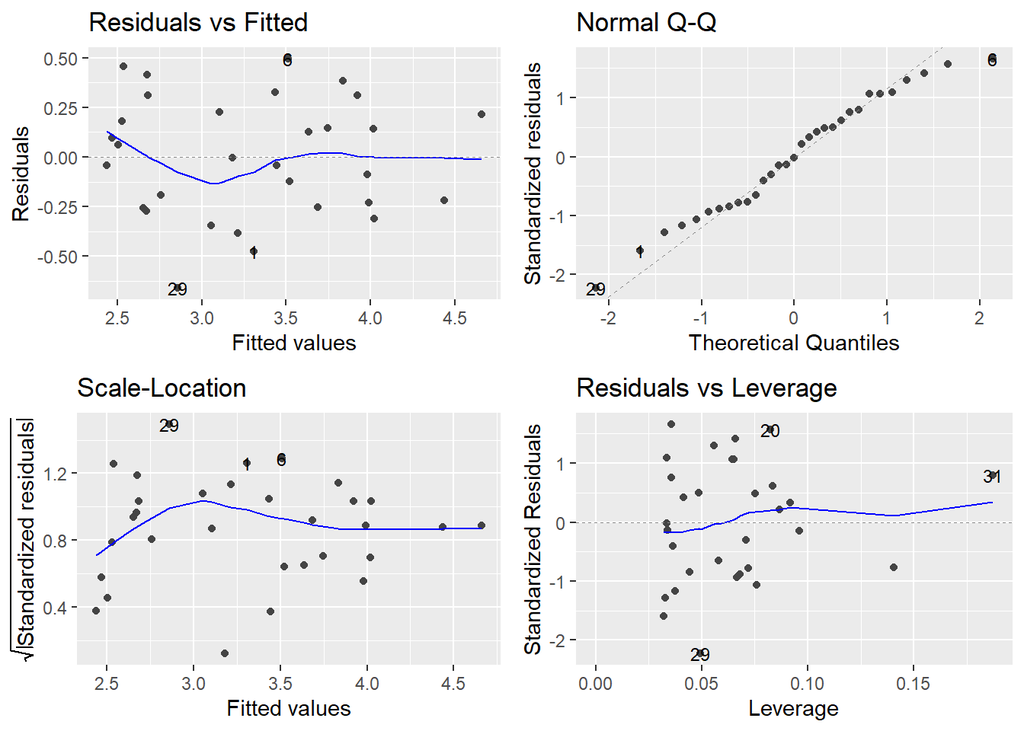

```r
autoplot(model2, label.repel = TRUE, label.size = 3)
```

```r
pred_log <- predict(model2, newdata = data.frame(Tonnage = 10000), interval = "confidence", level = 0.95)
exp(pred_log)
```

```
##       fit      lwr      upr
## 1 72.1966 58.63727 88.89141
```

The second model is log(Time) = 1.19 + 0.31 * Tonnage^{0.25}. The R-squared is 0.816. The predicted time when tonnage is 10,000 is 72.20, with a 95% confidence interval of [58.64, 88.89].

d,

```r
pred_log_10000 <- predict(model2, newdata = data.frame(Tonnage = 10000))
pred_log_160000 <- predict(model2, newdata = data.frame(Tonnage = 160000))
exp(pred_log_160000) - exp(pred_log_10000)
```

```
##        1
## 1516.026
```

```r
coef(model2)
```

```
##     (Intercept) I(Tonnage^0.25)
##       1.1884153       0.3090978
```

```r
exp(coef(model2) * 10000^0.25)
```

```
##     (Intercept) I(Tonnage^0.25)
##    144951.30599        21.99857
```

The predicted change in time when tonnage increases from 10,000 to 160,000 is 1516.03. For a 16-fold increase in tonnage (from x to 16x), the ratio y2 / y1 = exp(β₁ * x^{0.25}) = exp(0.31 * x^{0.25}). For x=10,000, the ratio is approximately 22.

e,

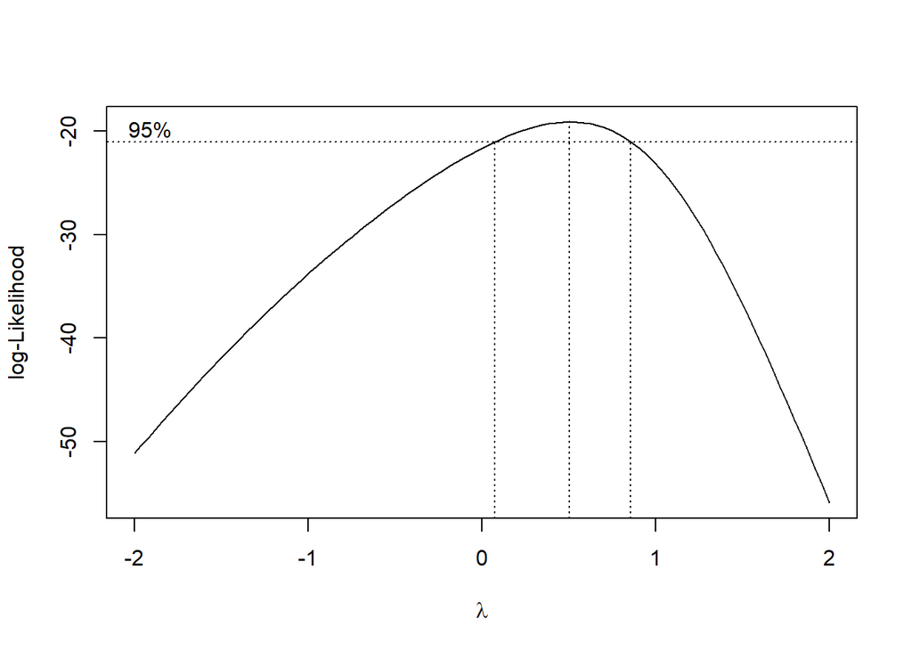

```r
boxcox(model1)
```